# Class 4

## Map with side effects: the walk function

### Side Effects

Side effects are usually described by two things:

- Describe things that happen beyond the results of a function
- Examples include: printing output, plo!ing, and saving files to disk

### Walk

`walk()` operates just like `map()` except it’s designed for functions that don’t return anything (side effects). You use `walk()` for functions with side effects like printing, plotting or saving.

Let’s check that our simulated samples are in fact what we think they are by plotting a histogram for each one.

Let’s see an example:

```r
library(dplyr)
library(purrr)
x <- list(1, "a", 3)
out <- x %>% walk(print)
```

```
## [1] 1
## [1] "a"
## [1] 3
```

Besides, `out` contain the original `x` object.

```r
str(out)
```

```
## List of 3
##  $ : num 1
##  $ : chr "a"
##  $ : num 3
```

### Walking over two or more arguments

As well as `map2`, exists `walk2`. Let’s review an example:

```r
f <- list(Normal = "rnorm", Uniform = "runif", Exp = "rexp")
```

```r
### Define params
params <- list(
  Normal = list(mean = 10),
  Uniform = list(min = 0, max = 5),
  Exp = list(rate = 5)
)
```

```r
# Assign the simulated samples to sims
sims <- invoke_map(f, params, n = 50)
```

```r
# Replace "Sturges" with reasonable breaks for each sample
breaks_list <- list(
  Normal = seq(6,16,0.5),
  Uniform = seq(0,5,0.25),
  Exp =  seq(0,1.5,0.1)
)
```

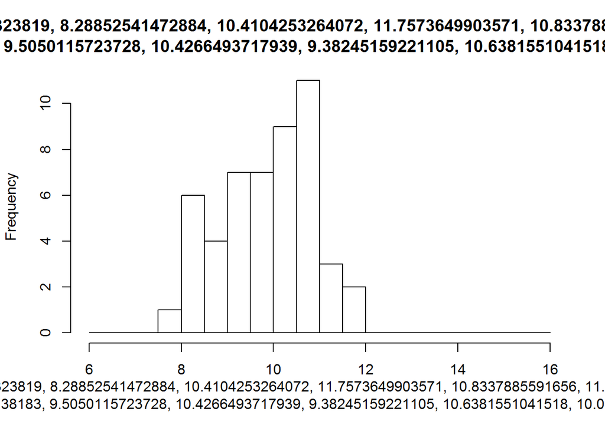

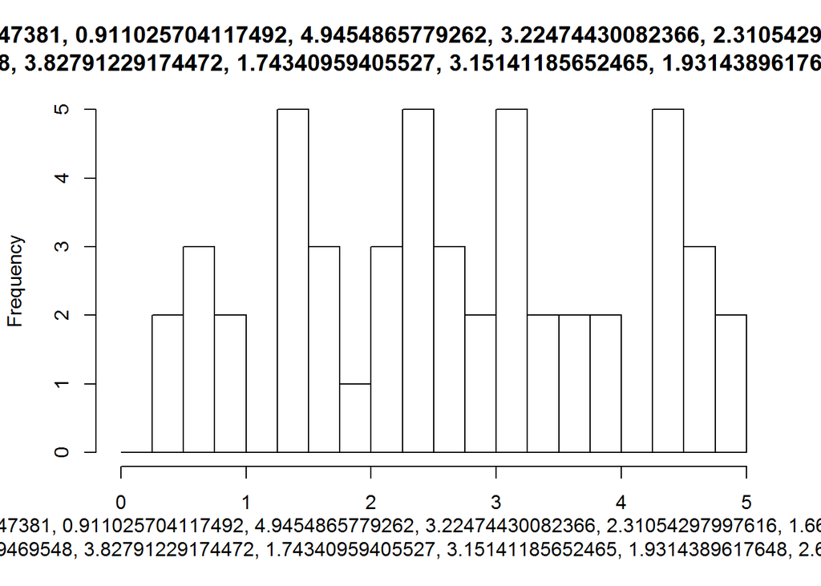

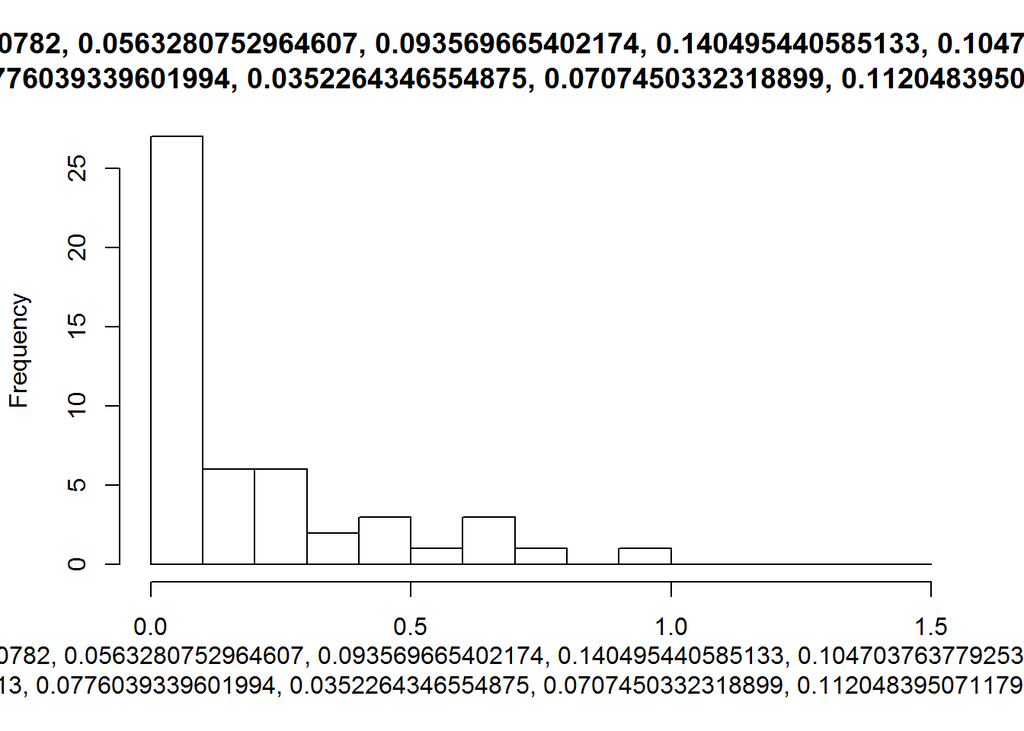

```r
### Use walk2() to make histograms with the right breaks
walk2(.x = sims, .y = breaks_list, .f = hist)
```

### Walk over multiple arguments

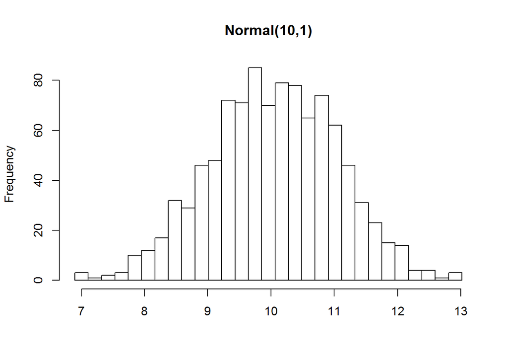

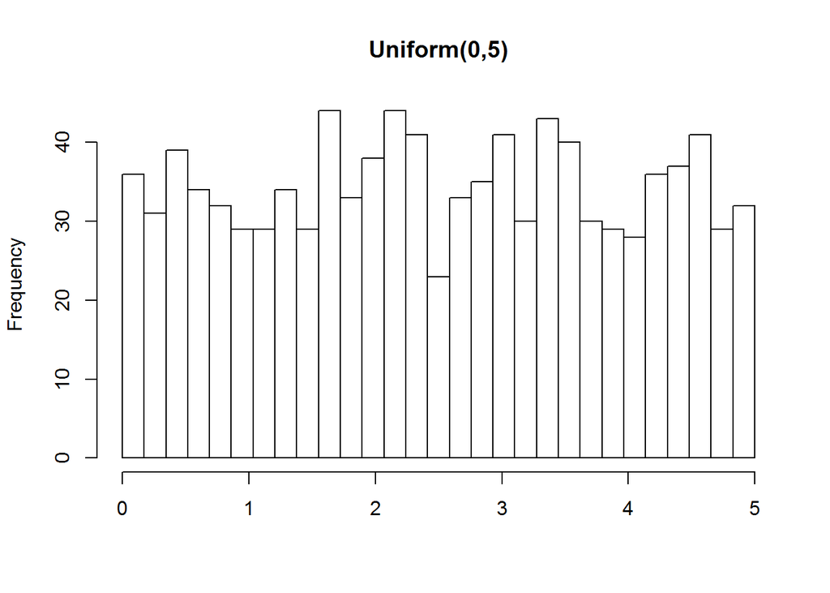

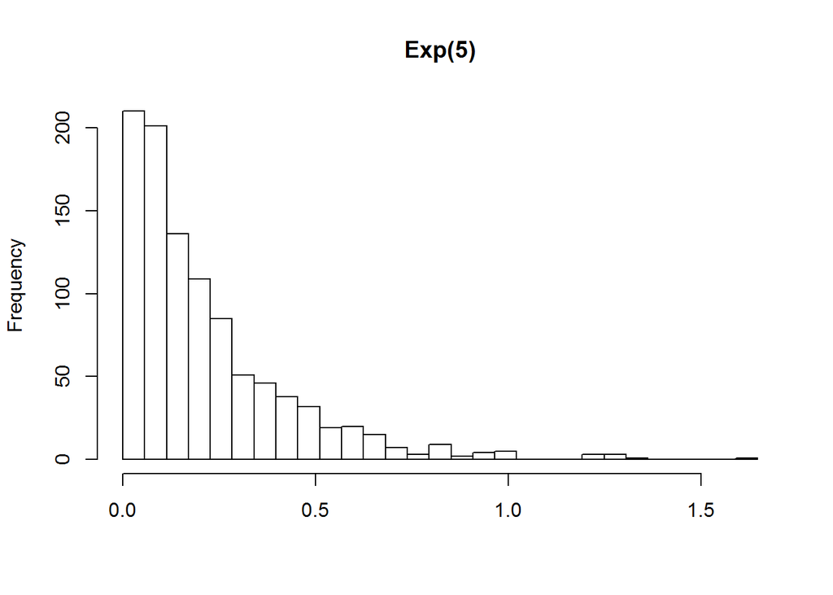

```r
# Increase sample size to 1000
sims <- invoke_map(f, params, n = 1000)

#Find breaks functions
find_breaks<- function(x) {
  rng <- range(x, na.rm = TRUE)
  seq(rng[1], rng[2], length.out = 30)
}

# Compute nice_breaks (don't change this)
nice_breaks <- map(sims, find_breaks)

# Create a vector nice_titles
nice_titles<- c("Normal(10,1)", "Uniform(0,5)", "Exp(5)")

# Use pwalk() instead of walk2()

arg<- list(x= sims,
           breaks= nice_breaks,
           main = nice_titles,
           xlab= ""
)
# First way
pwalk(.l = arg, hist)
```

```r
#Second way, we keep fixed the x label over all the plots
# arg<- list(x= sims,
#            breaks= nice_breaks,
#            main = nice_titles
# )
#
# pwalk(.l = arg, .f = hist, xlab="")
```

### Walking with pipes

One of the nice things about the walk() functions is that they return the object you passed to them. This means they can easily be used in pipelines (a pipeline is just a short way of saying “a statement with lots of pipes”). The following example ilustrates one of the most insteresting features:

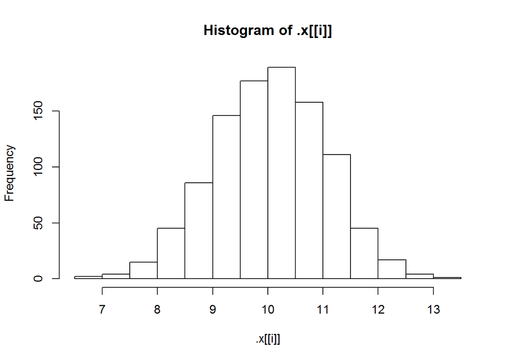

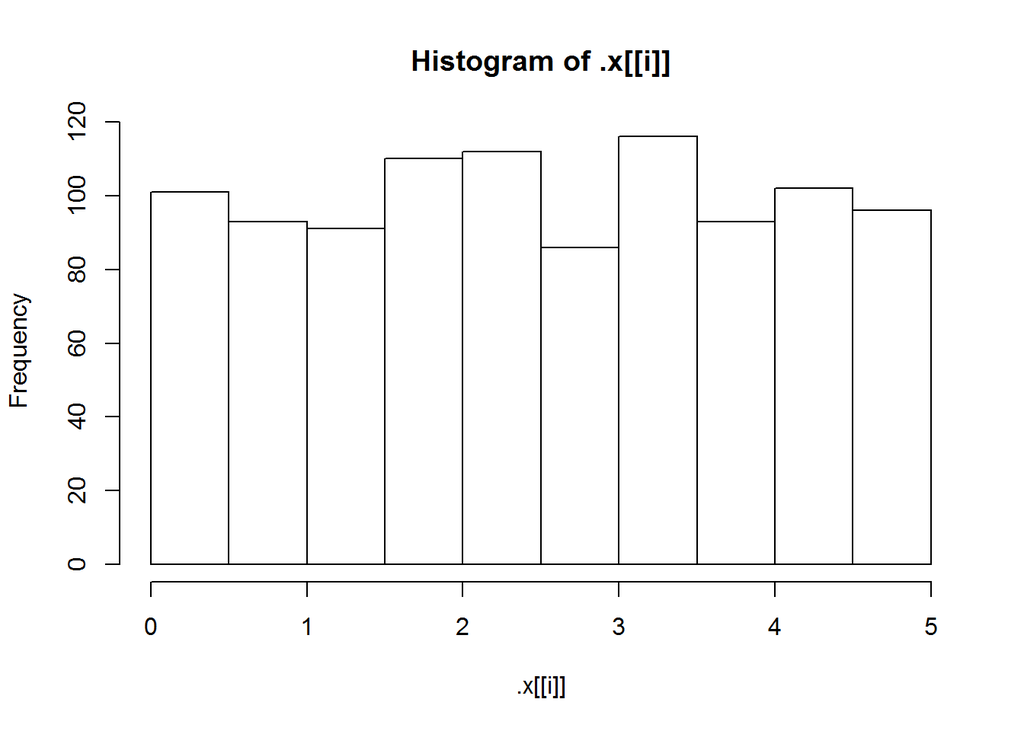

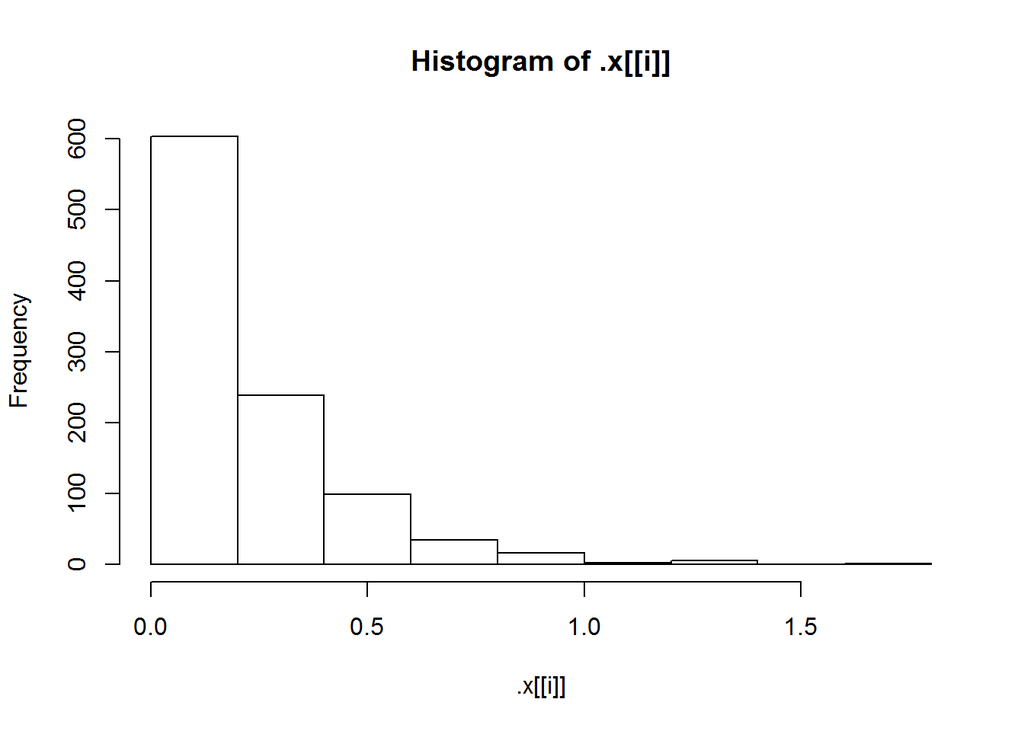

```
## $Normal
##    Min. 1st Qu.  Median    Mean 3rd Qu.    Max.
##   6.900   9.358  10.060  10.050  10.770  13.020
##
## $Uniform
##     Min.  1st Qu.   Median     Mean  3rd Qu.     Max.
## 0.000177 1.328000 2.468000 2.503000 3.679000 4.998000
##
## $Exp
##      Min.   1st Qu.    Median      Mean   3rd Qu.      Max.
## 0.0003583 0.0690700 0.1467000 0.2168000 0.2933000 1.6460000
```

```r
sims %>%
  walk(hist) %>%
        map(.f = summary)
```